# Fragile Family Analysis

## 2 Model Fitting

Next, we are going to fit the data to several models. Our goal here is to predict childhood wellbeing based on the answers of the abovementioned questions.

### Train/Test/Validation split

We first split data.fl to training, testing and validation set. The testing error is used to measure the performance of each model. The model with the least testing error will be further tested on the validation data.

### Model 1: Linear Regression (Can move to Appendix)

We start our exploration from fitting all the variables to a linear regression model.

Apparently the linear model with all variables doesn’t work well. The R-square is only 0.037, and most features are insignificant in 0.1 level.Non-linear relationship between those questions and wellbeing can be the main cause. We still conducted a backward model selection with Cp to see whether there are some interesting significant variables.

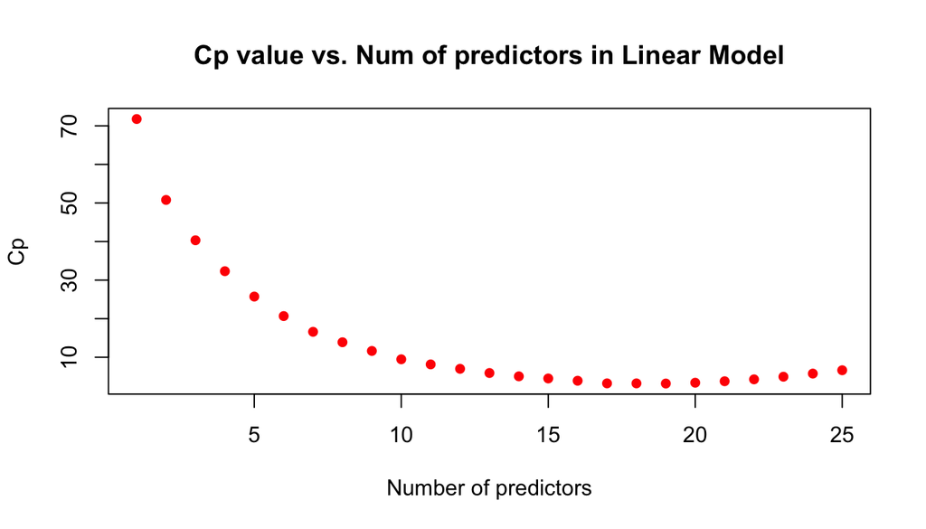

Here, 17 variables give the lowest Cp. The final lm model will use these 17 variables.

```
##  [1] "(Intercept)" "k5e2a"       "f1e3"        "m1a13"       "m1f5"
##  [6] "m1b18"       "m2d3a"       "m2h8e"       "m2h19b"      "p4b15"
## [11] "p4l11"       "p4l19"       "p4l43"       "m4i0g"       "m4h4"
## [16] "m4i0p"       "f4i8a1"      "f4a2"
```

```
##
## Call:
## lm(formula = wellbeing ~ k5e2a + f1e3 + m1a13 + m1f5 + m1b18 +
##     m2d3a + m2h8e + m2h19b + p4b15 + p4l11 + p4l19 + p4l43 +
##     m4i0g + m4h4 + m4i0p + f4i8a1 + f4a2, data = data.train)
##
## Residuals:
##     Min      1Q  Median      3Q     Max
## -71.656 -10.399   1.231  10.879  38.948
##
## Coefficients:
##             Estimate Std. Error t value Pr(>|t|)
## (Intercept)  57.3443     8.1123   7.069 1.97e-12 ***
## k5e2a        -0.4319     0.2074  -2.082  0.03744 *
## f1e3         -0.8215     0.3072  -2.674  0.00753 **
## m1a13         4.2726     2.2420   1.906  0.05679 .
## m1f5         -0.7434     0.4322  -1.720  0.08554 .
## m1b18        -2.2972     1.3998  -1.641  0.10090
## m2d3a        -1.8190     0.8206  -2.217  0.02672 *
## m2h8e         1.6965     0.7112   2.385  0.01714 *
## m2h19b        5.7857     3.0751   1.881  0.06001 .
## p4b15         1.4023     0.7112   1.972  0.04872 *
## p4l11         2.3553     0.4801   4.906 9.84e-07 ***
## p4l19        -2.0838     0.6803  -3.063  0.00221 **
## p4l43         0.8009     0.4293   1.865  0.06222 .
## m4i0g        -1.0454     0.6040  -1.731  0.08360 .
## m4h4         -1.7290     0.8603  -2.010  0.04455 *
## m4i0p        -1.2611     0.6431  -1.961  0.04998 *
## f4i8a1        2.6527     1.6074   1.650  0.09900 .
## f4a2         -0.4650     0.2353  -1.976  0.04824 *
## ---
## Signif. codes:  0 '***' 0.001 '**' 0.01 '*' 0.05 '.' 0.1 ' ' 1
##
## Residual standard error: 15.45 on 2782 degrees of freedom
## Multiple R-squared:  0.04792,    Adjusted R-squared:  0.0421
## F-statistic: 8.236 on 17 and 2782 DF,  p-value: < 2.2e-16
```

```
## [1] 291.6771
```

There’s little improvement. With 17 selected variables based on Cp value, the resulting linear model have a R-square of only 0.04 and the MSE on testing dataset is 291.6771.

### Linear model with LASSO

We then tried LASSO regularization on linear regression. It turns out the result is still bad. The MSE is 299.2521.

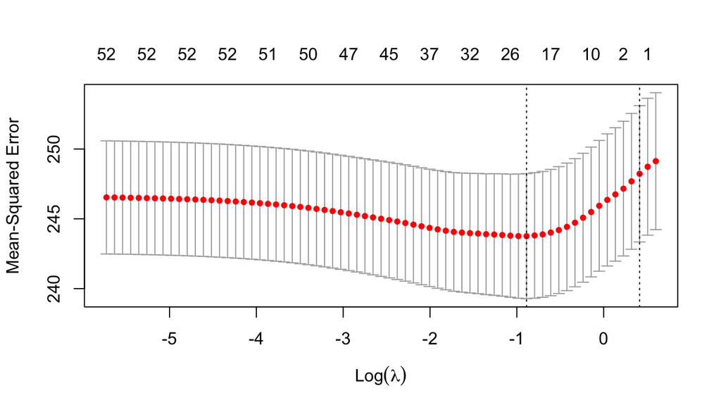

```
## [1] 299.2521
```

### Relaxed LASSO for linear model

A relaxed LASSO with variables from model 2 has a slightly better testing error (287.5523) but R-square is still low (0.03038)

```
##
## Call:
## lm(formula = wellbeing ~ ., data = data.fl.sub)
##
## Residuals:
##     Min      1Q  Median      3Q     Max
## -71.581 -10.082   1.524  11.418  38.021
##
## Coefficients:
##             Estimate Std. Error t value Pr(>|t|)
## (Intercept)  68.8265     1.8424  37.358  < 2e-16 ***
## m2h8e         2.8685     0.6385   4.493 7.26e-06 ***
## p4l11         2.3768     0.4427   5.369 8.45e-08 ***
## p4l32        -0.4912     0.4578  -1.073  0.28338
## m4h4         -2.4716     0.7579  -3.261  0.00112 **
## m4i0p        -1.8953     0.5851  -3.239  0.00121 **
## p4b9          1.3948     0.5814   2.399  0.01650 *
## ---
## Signif. codes:  0 '***' 0.001 '**' 0.01 '*' 0.05 '.' 0.1 ' ' 1
##
## Residual standard error: 15.76 on 3400 degrees of freedom
## Multiple R-squared:  0.03209,    Adjusted R-squared:  0.03038
## F-statistic: 18.79 on 6 and 3400 DF,  p-value: < 2.2e-16
```

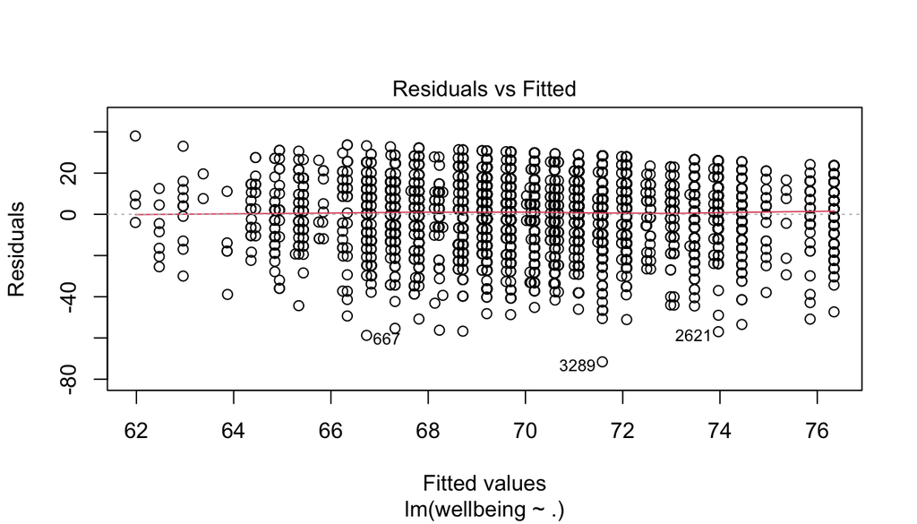

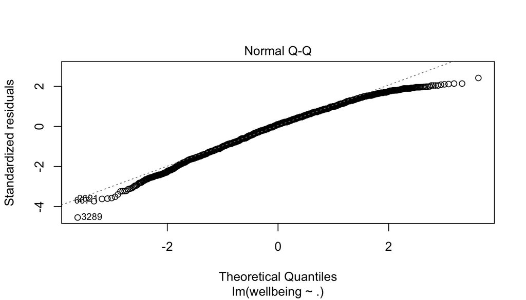

```
## [1] 287.5523
```

### Model 2: Logistic regression

Based on the results so far, we concluded that linear models is not suitable for our analysis. We decided to change it to a 0-1 classification problem by defining >70+ as good wellbeing (1) and try to fit a logistic regression model.

Again, most of the features are not significant. Let’s try logistic regression with LASSO:

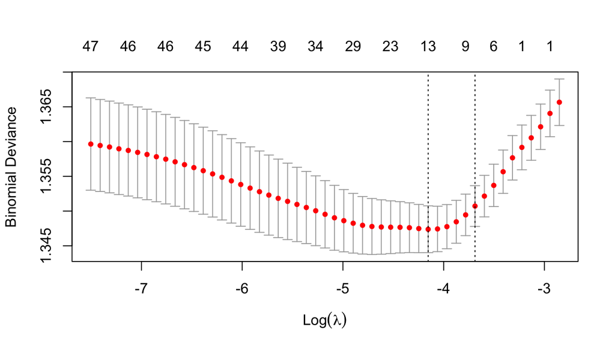

```
## [1] 0.3973941
```

It gives a testing error of 0.3973941, which is not bad.

### Model 3: Relaxed LASSO for logistic regression

```
##
## fit.1se.glm.pred    0    1
##                0  341  268
##                1  858 1333
```

```
## [1] 0.4104235
```

The relaxed LASSO model has a higher testing error (0.4104235).

### Model 4: Random forest

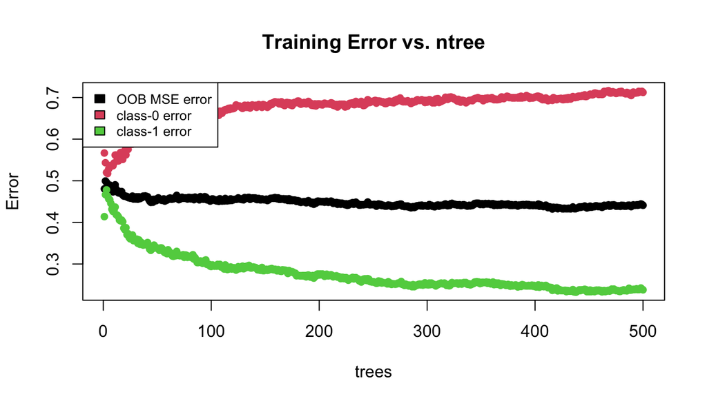

An ntree > 100 can settle the OOB testing errors. We will go with ntree = 300.

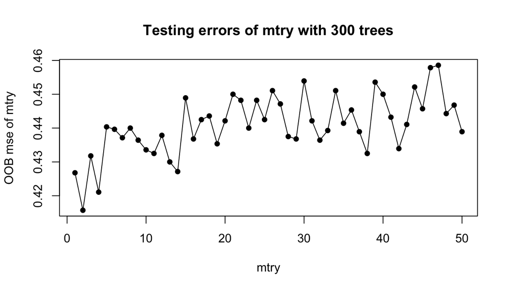

```
## [1] 0.3843648
```

The testing error for randomForest is 0.38, which is lower than previous logistic models.

### PCA first

We now want to build similar models with PCA-transformed data.

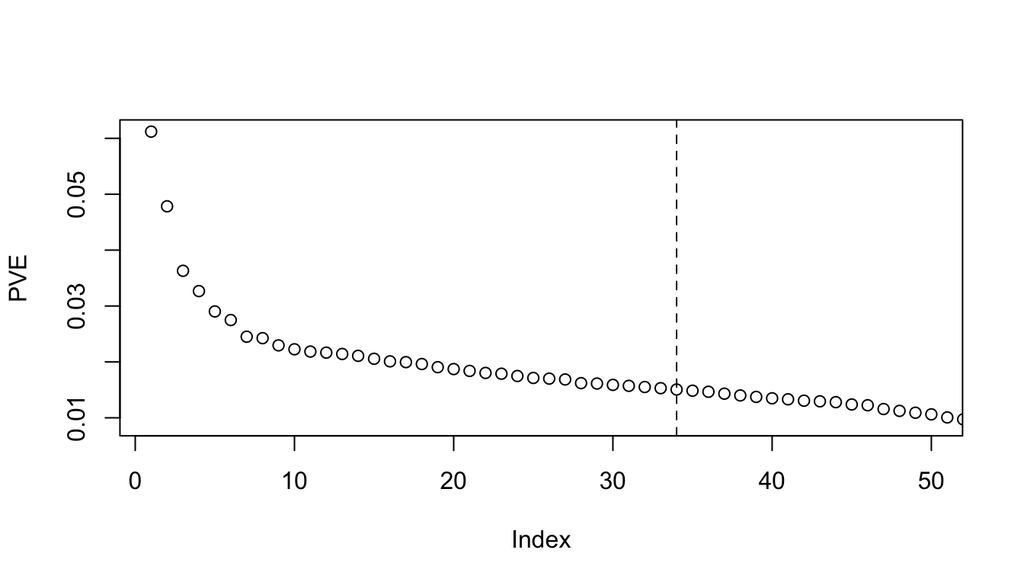

Based on the plots, we decided to use 34 PC scores to represent the original data set, since 34 PCs would capture about 76.5% of the variance. And then we extract PC scores from these 34 PCs and predict PC scores for testing data.

### Model 5: LASSO logistic model with PCA scores.

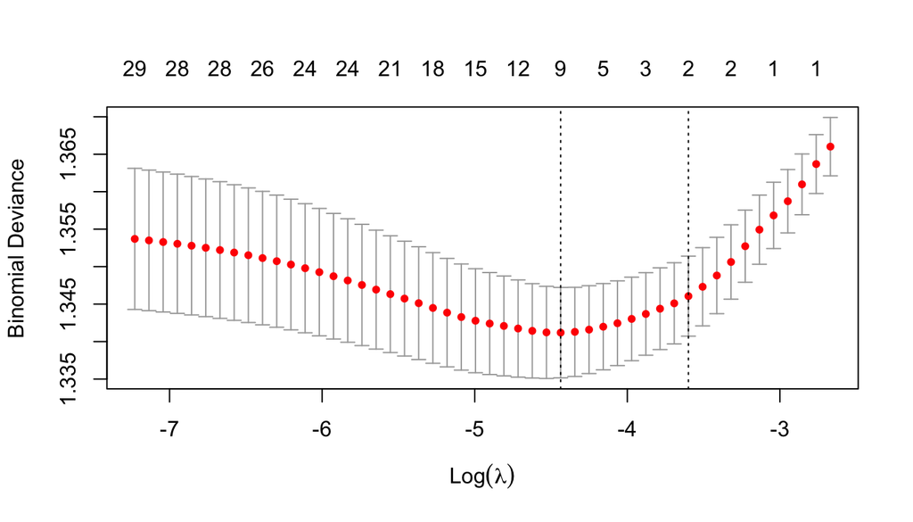

```
## [1] 0.3941368
```

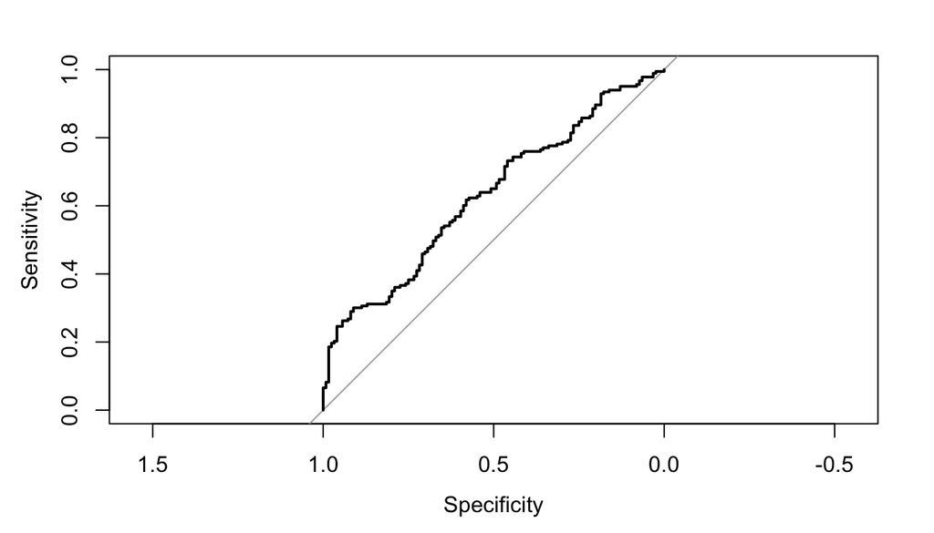

```
##
## Call:
## roc.default(response = data.test1$wellbeing, predictor = predict.glm.pca,     plot = T)
##
## Data: predict.glm.pca in 124 controls (data.test1$wellbeing 0) < 183 cases (data.test1$wellbeing 1).
## Area under the curve: 0.6296
```

LASSO with PCA scores gives a testing error of 0.3941368.

### Model 6: Random Forest with PCA scores

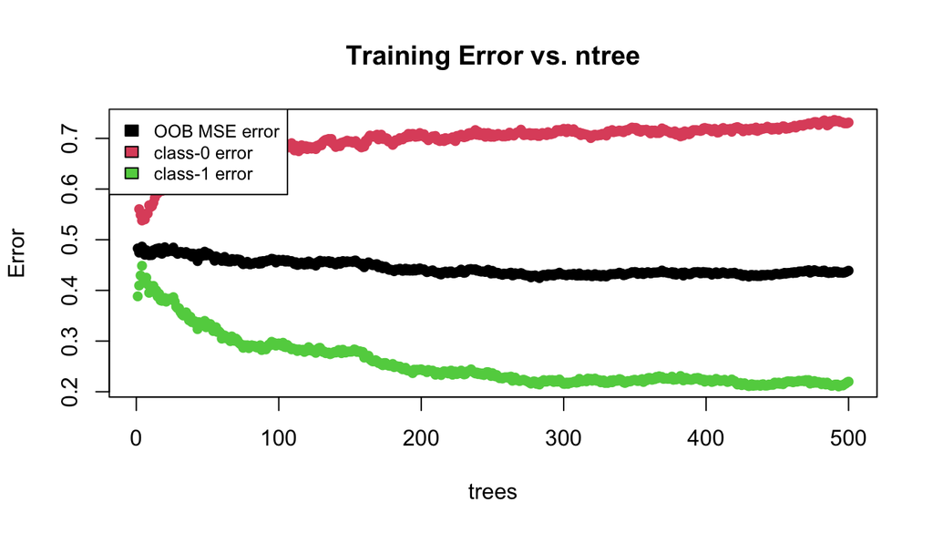

An ntree > 200 can settle the OOB testing errors. We will go with ntree = 300.

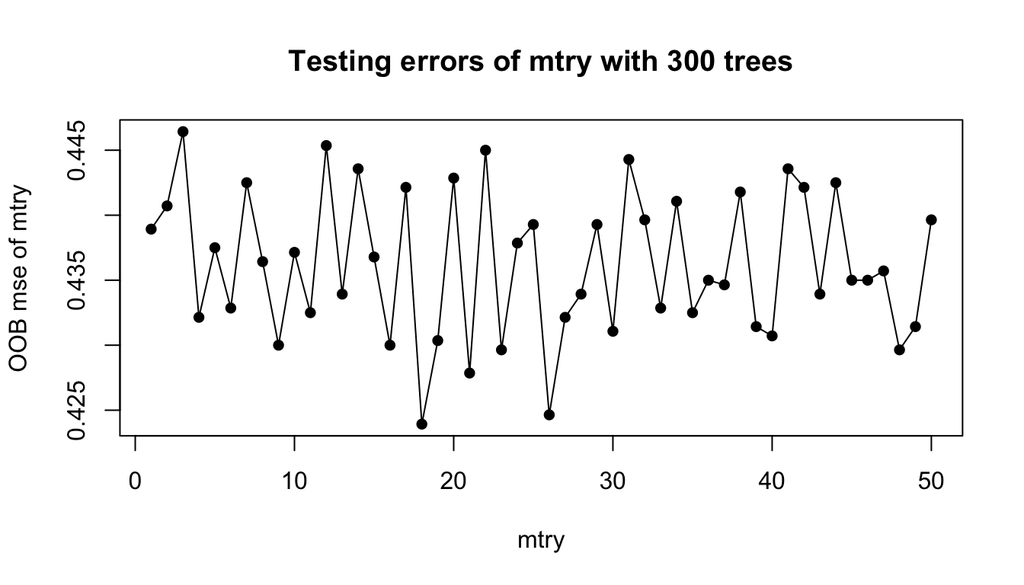

We’ll go with mtry=18 so our final model will use ntree=300 and mtry=18. (mtry=p/3)

```
## [1] 0.4364821
```

The testing error for randomForest model with PCA data is 0.44, which is higher than the LASSO logistic PCA model.

### Model 7: Baggings

So far, we have 6 models: 1, Linear model (not considered); 2, LASSO Logistic regression (testing error=0.3973941); 3, Relaxed LASSO Logistic regression (testing error=0.4104235); 4, Random forest(testing error=0.3843648); 5, LASSO Logistic regression with PCA (testing error=0.3941368); 6. Random forest with PCA (testing error=0.4364821). We then build an ensemble model by taking the average of predicted probabilities from model 2, 4 and 5, and make prediction based on the averaged probability.

```
## [1] 0.3941368
```

The testing error for this bagging model is 0.39.

### Final model and validation

Based on the testing error, our final model will be Model 4: Random forest.Here we will use the validation data to finally test the validation error.

```
## [1] 0.07666667
```

The final validation error is 0.076, which is pretty good.

```
## [1] "Constructing distance matrix..."
## [1] "Finding representative trees..."
```

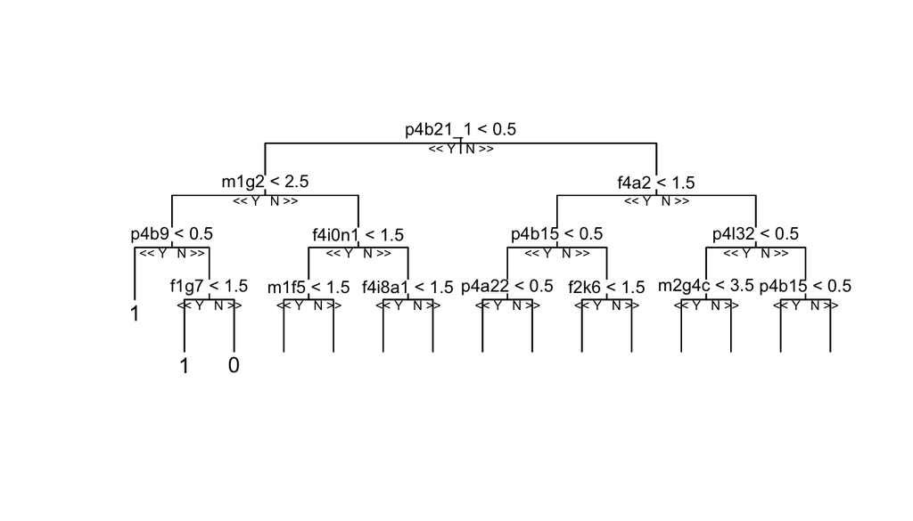

This code choose the best tree using d2 metric with the depth of 5. It is not even one of the trees in the randomForest, but it is easier to visualize. We can see that in the left branch, question f1g7 is important to classify wellbeing or not. This question asks: Are you very satisfied with yourself? 1-Yes, 2-No. Child answered No are more likely to be classified as in bad wellbeing condition. p4b9 looks to be another interesting question. It is: Is there a computer at home? 1-Yes, 0-No. Child answered No tend to have better psychological health condition. Maybe child can spend more time in other things if no computers to play at home. The first split is based on p4b21_1, which asks if child sleeps alone in room. 0-No, 1-Yes. It is hard to see the relationship between answers to this question and their wellbeing, but this question is important for this tree. This is just an example of our tree, but for randomForest, it is just hard to tell what each tree looks like given over 50 features.

# Appendix

## Appendix 1: Data Preparation

We fist select 12 columns based on domain knowledge that are related to children’s wellbeing. Since for each column, larger value stands for healthier coondition, we sum them up and to make the grades for “wellbeing”. We multiplied this grade by 4.16 to make the higest grade as 100 just for easier understanding.

We then selected more than 60 columns that we were interested. The total number of child in survey is 4800, so we dropped all columns with >2000 NAs. For the remained, we used a package called “mice” to impute the values. We used method=‘polr’ for ordinal categorical columns and method=‘pmm’ for continuous column. We checked the percentage for each level, which was similar before and after imputing. This indicates that the imputations did not change the distribution for each level, which is what we want.

*we have two choices, leave the categorical as categorical or change it to numeric. We tried both method and found numeric is better. We can change it to numeric directly because they are ordered categorical columns in our project.*